# Práctica 07 – Elección del valor óptimo de K para aplicar el algoritmo kmeans

### Introducción a la práctica

Un algoritmo de agrupamiento particiona un conjunto de objetos en grupos, de forma que los objetos dentro de un grupo son más similares unos a otros que aquellos objetos que pertenecen a otros grupos [1]. La mayoría de los algoritmos de agrupamiento, como kmeans por ejemplo, dependen de asunciones sobre el número de grupos en que se divide un data set a fin de que puedan ejecutarse correctamente [idem]. Como resultado de lo anterior, los grupos encontrados por un algoritmo de agrupamiento requieren de cierto análisis de su validez [idem], y este análisis es de suma importancia para tener resultados confiables.

El entorno R proporciona varios paquetes que apoyan en la tarea de la determinación del número óptimo de grupos (valor k) en un algoritmo de agrupamiento, algunos de estos paquetes son factoextra [2] y NbClust [1], por ejemplo. En la presente práctica utilizaremos el segundo de los mencionados.

El paquete NbClust contiene la biblioteca del mismo nombre, la cual provee la función NbClust() para realizar el análisis del valor óptimo de k a ser usado por un algoritmo de agrupamiento [1]. Para poder esa función, lo primero que debemos hacer es instalar el paquete NbClust y la biblioteca del mismo nombre, como se indica a continuación:

```r
library("NbClust")
```

Para ejemplificar el uso de la función NbClust() utilizaremos el data set Iris , provisto por el entorno de R. Como aplicaremos un algoritmo de aprendizaje no supervisado al data set, debemos eliminar la columna de las etiquetas del tipo de flor (columna cinco del data set, llamada Species ). Además, como tratamiento básico de datos, normalizaremos el data set Iris usando la media y la desviación estándar de los datos como referencia, tratamiento que recibe el nombre de escalamiento. Para lo anterior, tecleamos el siguiente comando:

```r
norm_data <- scale(iris[, -5])
```

Para realizar el análisis del número óptimo de grupos al aplicar un algoritmo de agrupamiento, debemos usar la función NbClust() de la siguiente forma:

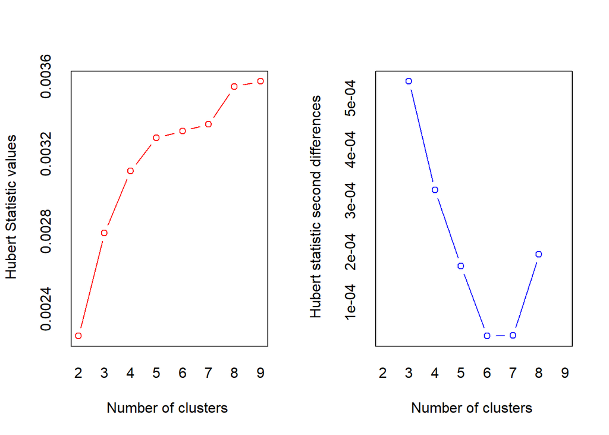

```
## *** : The Hubert index is a graphical method of determining the number of clusters.
##                 In the plot of Hubert index, we seek a significant knee that corresponds to a
##                 significant increase of the value of the measure i.e the significant peak in Hubert
##                 index second differences plot.
##
```

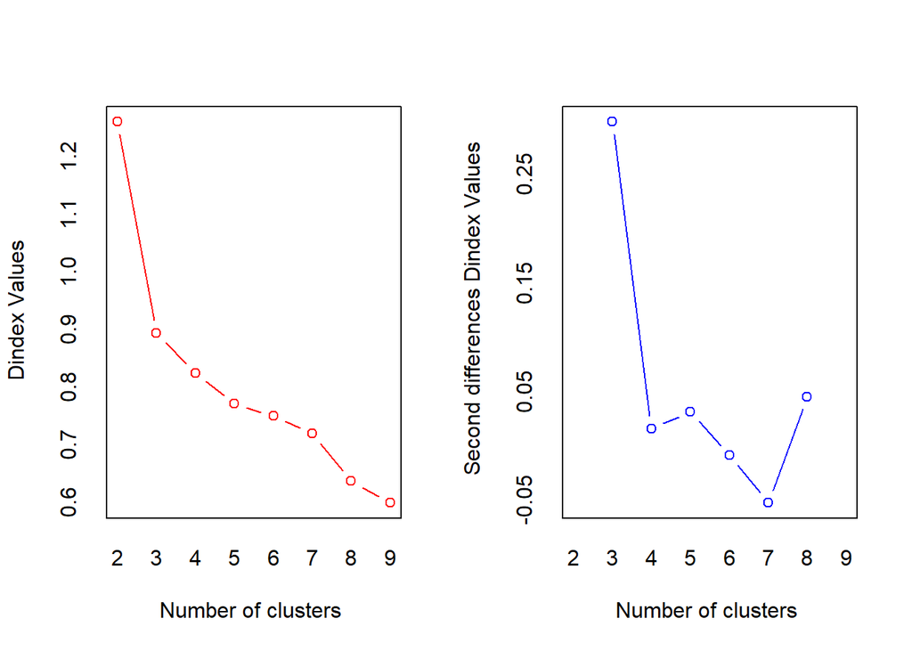

```
## *** : The D index is a graphical method of determining the number of clusters.
##                 In the plot of D index, we seek a significant knee (the significant peak in Dindex
##                 second differences plot) that corresponds to a significant increase of the value of
##                 the measure.
##
## * Among all indices:
## * 2 proposed 2 as the best number of clusters
## * 19 proposed 3 as the best number of clusters
## * 2 proposed 9 as the best number of clusters
##
##                    ***** Conclusion *****
##
## * According to the majority rule, the best number of clusters is  3
##
##
```

```
## $All.index
##       KL       CH Hartigan     CCC    Scott Marriot     TrCovW   TraceW
## 2 1.1854 151.6332 137.0327 -1.7090 206.2459 4042611 11446.7289 294.3866
## 3 9.8471 213.0817  33.2185  3.3712 444.9163 1852777  1065.2914 152.8569
## 4 1.3651 183.9682  24.9638  2.0682 543.6783 1705121   900.8342 124.6818
## 5 2.2951 166.6596  10.6281  0.4146 592.5766 1923092   562.5608 106.4760
## 6 2.7125 144.2243  12.7058 -0.7426 633.8818 2102674   558.6742  99.2046
## 7 0.0462 131.9862  39.5776 -1.2574 662.7020 2361686   432.8320  91.1610
## 8 2.7803 149.0463  19.9304  1.3079 781.5413 1396790   430.6392  71.3999
## 9 0.5276 150.1464  32.3094  2.0036 848.5792 1130685   285.0416  62.6120
##   Friedman  Rubin Cindex     DB Silhouette   Duda Pseudot2  Beale Ratkowsky
## 2  38.3959 2.0245 0.2978 0.9735     0.4408 0.2934 170.9649 5.7326    0.4606
## 3  53.5029 3.8991 0.3247 0.8581     0.4496 0.7005  32.0629 1.0185    0.4958
## 4  63.1994 4.7802 0.3085 0.9581     0.4106 0.5462  39.0434 1.9637    0.4431
## 5  64.5874 5.5975 0.3486 0.9262     0.3521 0.6102  14.0540 1.4752    0.4047
## 6  71.9579 6.0078 0.3922 0.9569     0.3107 0.3089  20.1316 4.8602    0.3722
## 7  72.7720 6.5379 0.4288 0.8597     0.3076 0.6359  36.6526 1.3613    0.3476
## 8  80.5472 8.3474 0.3937 0.9451     0.3303 0.6792  19.8416 1.1140    0.3314
## 9  85.6861 9.5189 0.3828 0.9766     0.3421 0.4147  56.4663 3.3249    0.3151
##       Ball Ptbiserial   Frey McClain   Dunn Hubert SDindex Dindex   SDbw
## 2 147.1933     0.5970 0.0616  0.5265 0.0412 0.0023  2.0588 1.2595 1.1052
## 3  50.9523     0.7169 0.7401  0.6296 0.0580 0.0028  1.5878 0.8925 0.3975
## 4  31.1704     0.7030 0.8948  0.7655 0.0623 0.0031  1.9156 0.8236 0.4585
## 5  21.2952     0.6892 1.3879  0.8368 0.0740 0.0033  1.5924 0.7703 0.3046
## 6  16.5341     0.6817 0.4503  0.8664 0.0842 0.0033  1.8236 0.7485 0.2503
## 7  13.0230     0.6815 1.1435  0.8708 0.0927 0.0034  1.7017 0.7183 0.1602
## 8   8.9250     0.5977 1.0644  1.2698 0.0990 0.0035  1.9947 0.6356 0.1434
## 9   6.9569     0.5491 0.8307  1.5619 0.1044 0.0036  2.5046 0.5981 0.1335
##
## $All.CriticalValues
##   CritValue_Duda CritValue_PseudoT2 Fvalue_Beale
## 2         0.6044            46.4793       0.0002
## 3         0.6106            47.8328       0.3979
## 4         0.5522            38.1140       0.1017
## 5         0.4284            29.3527       0.2166
## 6         0.2316            29.8538       0.0031
## 7         0.5921            44.0831       0.2478
## 8         0.5362            36.3229       0.3517
## 9         0.5291            35.6039       0.0120
##
## $Best.nc
##                     KL       CH Hartigan    CCC    Scott Marriot   TrCovW
## Number_clusters 3.0000   3.0000   3.0000 3.0000   3.0000       3     3.00
## Value_Index     9.8471 213.0817 103.8142 3.3712 238.6703 2042179 10381.44
##                   TraceW Friedman   Rubin Cindex     DB Silhouette   Duda
## Number_clusters   3.0000    3.000  3.0000 2.0000 3.0000     3.0000 3.0000
## Value_Index     113.3546   15.107 -0.9934 0.2978 0.8581     0.4496 0.7005
##                 PseudoT2  Beale Ratkowsky   Ball PtBiserial Frey McClain   Dunn
## Number_clusters   3.0000 3.0000    3.0000  3.000     3.0000    1  2.0000 9.0000
## Value_Index      32.0629 1.0185    0.4958 96.241     0.7169   NA  0.5265 0.1044
##                 Hubert SDindex Dindex   SDbw
## Number_clusters      0  3.0000      0 9.0000
## Value_Index          0  1.5878      0 0.1335
##
## $Best.partition
##   [1] 1 1 1 1 1 1 1 1 1 1 1 1 1 1 1 1 1 1 1 1 1 1 1 1 1 1 1 1 1 1 1 1 1 1 1 1 1
##  [38] 1 1 1 1 2 1 1 1 1 1 1 1 1 3 3 3 2 3 2 3 2 3 2 2 3 2 3 3 3 3 2 2 2 3 3 3 3
##  [75] 3 3 3 3 3 2 2 2 2 3 3 3 3 2 3 2 2 3 2 2 2 3 3 3 2 2 3 3 3 3 3 3 2 3 3 3 3
## [112] 3 3 3 3 3 3 3 3 2 3 3 3 3 3 3 3 3 3 3 3 3 3 3 3 3 3 3 3 3 3 3 3 3 3 3 3 3
## [149] 3 3
```

```r
NbClust(norm_data,distance="euclidean",min.nc=2,max.nc=9,method="complete")
```

La descripción de los argumentos utilizados es la siguiente:

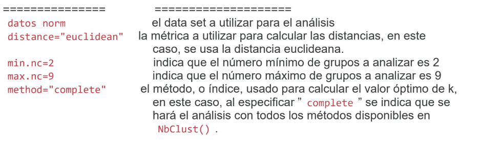

La función NbClust() genera varios resultados. En primer lugar, la figura 1 muestra parte de la salida en la cual se observa como conclusión que, de todos los índices calculados, el valor más prevalente como número óptimo de grupos es 3. Este valor, como se recordará, coincide con el número natural de grupos existentes en el data set Iris , los cuales son flores iris de tres tipos: setosa, versicolor y virginica.

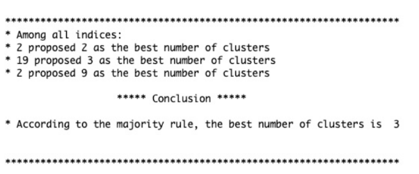

**Figura 1.** Resultado parcial de la ejecución de la función NbClust() : conclusión sobre cuál valor de k a usar.

Otra parte importante de la salida que genera la aplicación de NbClust() se muestra en la figura 2. Esa figura muestra una gráfica con el número máximo de índices de diferencias dindex encontrados por la función. Éste valor es generado por algunos algoritmos usados para buscar el valor óptimo de k [1]. Por ejemplo, el valor dindex (ver figura 2) se basa en la ganancia de agrupamiento en la inercia inter-grupo, la cual mide el grado de homogeneidad entre los datos asociados a un grupo [idem]. Así, el dindex calcula las distancias con respecto al punto de referencia que representa el perfil de un grupo, el cual, en la mayoría de los métodos es un centroide. Como se observa en la figura 2, el valor máximo de las segundas diferencias ( dindex ) es, efectivamente, el número 3. Es importante considerar que no siempre los valores de dindex coinciden con el valor óptimo de k, por lo que es mejor basarse en el resumen de resultados mostrado en la figura 1.

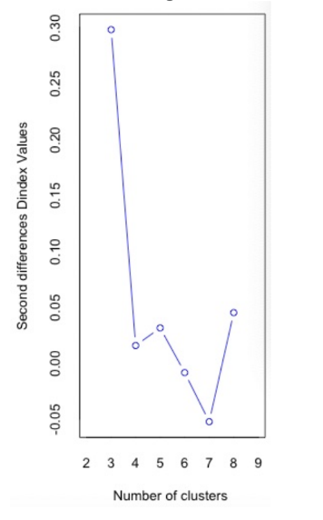

**Figura 2.** Resultado parcial de la ejecución de la función NbClust(): valores de las segundas diferencias.

### Cuestionamiento básico previo a la práctica (problematización, hipótesis, preguntas guía)

**¿Cómo podrías obtener en R el número optimo de grupos a encontrar mediante el algoritmo kmeans?**

De tres formas

- Con la libreria utilizada en la introducción (NbClus)
- Con la libreria factoextra graficando el método fviz_nbclust pasando el parametro method = “wss”
- Con la libreria factoextra aplicando el método fviz_nbclust con el parametro method igual a “silhouette”

### Procedimiento o desarrollo

1. Importa a R el data set “Faithful_data.xlsx”. El data set contiene información de las erupciones del jeyser Faithful, en Yellowstone. Contiene dos propiedades: el tiempo de erupción del jeyser Faithful en minutos (variable “eruptions”) y el tiempo de espera de la siguiente erupción en el mismo jeyser (variable “waiting”)

```r
library("readxl")

#getting the dataframe from the path
df_volcano <- read_excel("C:/Users/juan_/OneDrive - Universidad de Colima/Escritorio/6to/practica 7 valor optimo de k - MdD/datasets/Faithful_data.xlsx")
```

2. Realiza la transformación de datos necesaria para determinar el número óptimo de grupos a considerar si se quieren agrupar los datos de las propiedades eruptions y waiting. Luego determina tal valor.

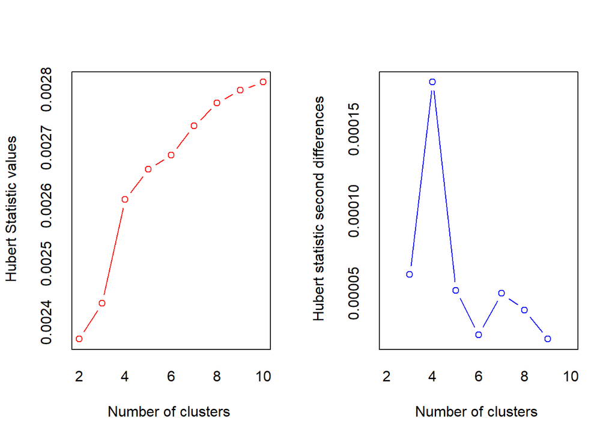

```
## *** : The Hubert index is a graphical method of determining the number of clusters.
##                 In the plot of Hubert index, we seek a significant knee that corresponds to a
##                 significant increase of the value of the measure i.e the significant peak in Hubert
##                 index second differences plot.
##
```

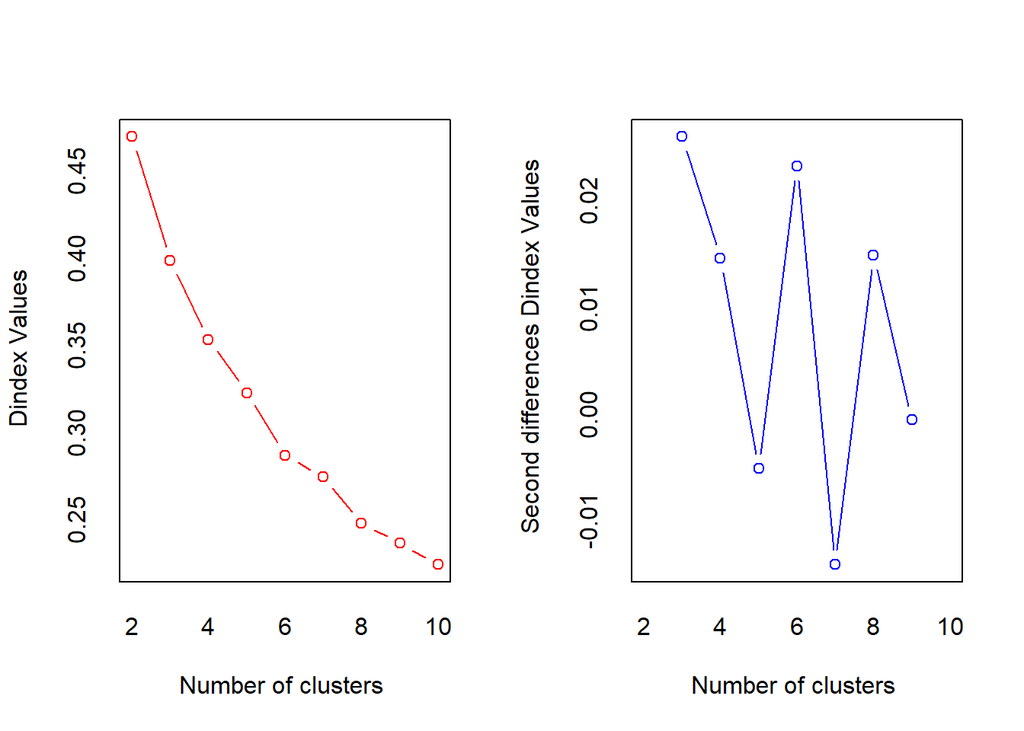

```
## *** : The D index is a graphical method of determining the number of clusters.
##                 In the plot of D index, we seek a significant knee (the significant peak in Dindex
##                 second differences plot) that corresponds to a significant increase of the value of
##                 the measure.
##
## * Among all indices:
## * 14 proposed 2 as the best number of clusters
## * 3 proposed 3 as the best number of clusters
## * 2 proposed 4 as the best number of clusters
## * 3 proposed 6 as the best number of clusters
## * 1 proposed 7 as the best number of clusters
## * 1 proposed 8 as the best number of clusters
##
##                    ***** Conclusion *****
##
## * According to the majority rule, the best number of clusters is  2
##
##
```

```
## $All.index
##         KL        CH Hartigan     CCC     Scott  Marriot   TrCovW  TraceW
## 2  38.9033 1575.7836 111.2995 11.6407  647.4636 5124.059 829.4175 79.2834
## 3   1.2136 1163.9995  73.1674  5.5197  813.5811 6259.817 782.0708 56.1410
## 4   1.0356 1007.6989  52.7516  3.5593  916.6329 7619.022 394.8276 44.1360
## 5   0.3682  914.3001  95.2496  3.8619 1033.3220 7751.846 168.5558 36.8773
## 6   1.1062 1007.6359  11.5600  5.8413 1176.5743 6592.359 156.3280 27.1808
## 7   1.3064  874.8140  64.4926  3.6368 1201.5450 8185.864 131.1843 26.0488
## 8   7.8007  937.9882  29.6889  4.9323 1329.5074 6679.355 106.6837 20.9502
## 9   0.7212  913.2768  24.7739  4.5536 1377.9424 7074.647  86.4678 18.8323
## 10  1.2174  887.6360  29.8492  4.1158 1431.7553 7166.355  78.8412 17.2111
##    Friedman   Rubin Cindex     DB Silhouette   Duda Pseudot2   Beale Ratkowsky
## 2   14.5077  6.8362 0.2521 0.3913     0.7452 0.6100 110.6187  0.6357    0.6532
## 3   19.8653  9.6543 0.2686 0.9212     0.4892 1.9186 -63.6773 -0.4716    0.5465
## 4   23.0950 12.2802 0.3037 1.0748     0.3806 2.7700 -70.9281 -0.6217    0.4792
## 5   30.0380 14.6974 0.2675 1.0909     0.3572 1.2811 -13.1665 -0.2138    0.4317
## 6   38.2115 19.9405 0.3126 0.9204     0.3931 2.8545 -29.8852 -0.6172    0.3979
## 7   40.2263 20.8071 0.2701 0.9723     0.3548 1.1843  -7.4703 -0.1427    0.3688
## 8   52.3974 25.8709 0.3010 1.0077     0.3512 0.7073  16.5531  0.4023    0.3466
## 9   56.4316 28.7803 0.2865 0.9313     0.3675 1.4920 -18.7963 -0.3133    0.3275
## 10  63.0843 31.4913 0.2780 0.9105     0.3705 1.8394  -8.2144 -0.4057    0.3112
##       Ball Ptbiserial   Frey McClain   Dunn Hubert SDindex Dindex   SDbw
## 2  39.6417     0.9033 4.8833  0.2111 0.0573 0.0024  1.5580 0.4696 0.2444
## 3  18.7137     0.6760 2.5094  0.4913 0.0358 0.0024  3.7780 0.3984 0.3947
## 4  11.0340     0.6027 2.2856  0.6569 0.0441 0.0026  3.5713 0.3532 0.3916
## 5   7.3755     0.5264 0.4993  0.8959 0.0169 0.0027  4.2908 0.3226 0.3894
## 6   4.5301     0.5117 1.6303  0.9209 0.0460 0.0027  4.6482 0.2869 0.6129
## 7   3.7213     0.4811 1.3404  1.0379 0.0428 0.0027  5.1079 0.2745 0.2251
## 8   2.6188     0.4395 0.7057  1.2207 0.0517 0.0028  5.7215 0.2480 0.3495
## 9   2.0925     0.4291 0.9588  1.2574 0.0517 0.0028  5.5316 0.2364 0.5573
## 10  1.7211     0.4198 1.0665  1.2994 0.0517 0.0028  5.6621 0.2243 0.2711
##
## $All.CriticalValues
##    CritValue_Duda CritValue_PseudoT2 Fvalue_Beale
## 2          0.4946           176.7712       0.5302
## 3          0.3824           214.7768       1.0000
## 4          0.2814           283.5052       1.0000
## 5          0.2915           145.8308       1.0000
## 6          0.1432           275.2767       1.0000
## 7         -0.0027        -17528.6873       1.0000
```

[output cut: 12 more lines]

```
## Number_clusters 2.0000    2.0000  3.000     2.0000 4.0000  2.0000 2.0000      0
## Value_Index     0.6357    0.6532 20.928     0.9033 2.2856  0.2111 0.0573      0
##                 SDindex Dindex   SDbw
## Number_clusters   2.000      0 7.0000
## Value_Index       1.558      0 0.2251
##
## $Best.partition
##   [1] 1 2 1 2 1 2 1 1 2 1 2 1 1 2 1 2 2 1 2 1 2 2 1 1 1 1 2 1 1 1 1 1 1 1 1 2 2
##  [38] 1 2 1 1 2 1 2 1 1 1 2 1 2 1 1 2 1 2 1 1 2 1 1 2 1 2 1 2 1 1 1 2 1 1 2 1 1
##  [75] 2 1 2 1 1 1 1 1 1 2 1 1 1 1 2 1 2 1 2 1 2 1 1 1 2 1 2 1 2 1 1 2 1 2 1 1 1
## [112] 2 1 1 2 1 2 1 2 1 2 1 1 2 1 1 2 1 2 1 2 1 2 1 2 1 2 1 2 1 1 2 1 1 1 2 1 2
## [149] 1 2 1 1 2 1 1 1 1 1 2 1 2 1 2 1 1 1 2 1 2 1 2 2 1 1 1 1 1 2 1 1 2 1 1 1 2
## [186] 1 1 2 1 2 1 2 1 1 1 1 1 1 2 1 2 1 1 2 1 2 1 1 2 1 2 1 2 1 2 1 2 1 2 1 2 1
## [223] 2 1 1 1 1 1 1 1 1 2 1 2 1 2 2 1 1 2 1 2 1 2 1 1 2 1 2 1 2 1 1 1 1 1 1 1 2
## [260] 1 1 1 2 1 2 2 1 1 2 1 2 1
```

```r
#normalization
norm_data <- scale(df_volcano)

#getting the optimal k value
NbClust(norm_data,distance="euclidean",min.nc=2,max.nc=10,method="kmeans")
```

3. Toma en cuenta el número de grupos determinado en el punto 2 y realiza el agrupamiento de los datos con el algoritmo kmeans. Comenta los resultados obtenidos.

```r
#k-means algorithm
clusters = kmeans(df_volcano, 2, nstart = 100)
print(clusters)
```

```
## K-means clustering with 2 clusters of sizes 172, 100
##
## Cluster means:
##   eruptions  waiting
## 1   4.29793 80.28488
## 2   2.09433 54.75000
##
## Clustering vector:
##   [1] 1 2 1 2 1 2 1 1 2 1 2 1 1 2 1 2 2 1 2 1 2 2 1 1 1 1 2 1 1 1 1 1 2 1 1 2 2
##  [38] 1 2 1 1 2 1 2 1 1 2 2 1 2 1 1 2 1 2 1 1 2 1 1 2 1 2 1 2 1 1 1 2 1 1 2 1 1
##  [75] 2 1 2 1 1 1 1 1 1 2 1 1 1 1 2 1 2 1 2 1 2 1 1 1 2 1 2 1 2 1 1 2 1 2 1 1 1
## [112] 2 1 1 2 1 2 1 2 1 2 1 1 2 1 1 2 1 2 1 2 1 2 1 2 1 2 1 2 1 1 2 1 1 1 2 1 2
## [149] 1 2 1 1 2 1 1 1 1 1 2 1 2 1 2 1 2 1 2 1 2 1 2 2 1 1 1 1 1 2 1 1 2 1 1 1 2
## [186] 1 1 2 1 2 1 2 1 1 1 1 1 1 2 1 2 1 1 2 1 2 1 1 2 1 1 1 2 1 2 1 2 1 2 1 2 1
## [223] 2 1 1 1 1 1 1 1 1 2 1 2 1 2 2 1 1 2 1 2 1 2 1 1 2 1 2 1 2 1 1 1 1 1 1 1 2
## [260] 1 1 1 2 1 2 2 1 1 2 1 2 1
##
## Within cluster sum of squares by cluster:
## [1] 5445.591 3456.178
##  (between_SS / total_SS =  82.4 %)
##
## Available components:
##
## [1] "cluster"      "centers"      "totss"        "withinss"     "tot.withinss"
## [6] "betweenss"    "size"         "iter"         "ifault"
```

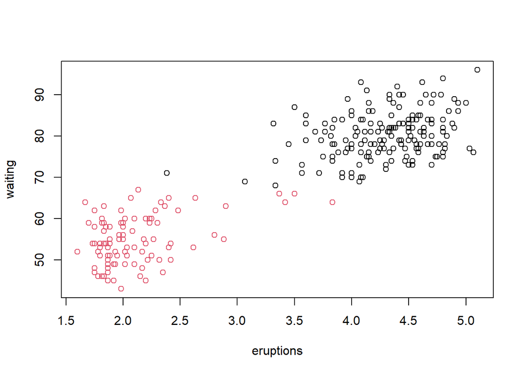

```r
#showing the graph of the clusters
plot(df_volcano, col = clusters$cluster)
```

Se puede observar en la gráfica que 2 parece ser el mejor valor de k, ya que se observan 2 nubes de puntos, también se puede ver que el algoritmo no funcionó muy bien con algunos outliers, como los que se encuentran entre los valores (3.2-4) del eje x y (60-70) del eje y

4. Documenta los comandos y resultados obtenidos en los puntos 1-3.

### Conclusiones

   En la documentación de NbClust se especifica que el valor del parámetro method puede ser un algoritmo en especifico, por lo que para el último ejercicio decidí probar como valor de method “kmeans” y “complete” en ambas ejecuciones el resultado fue 2